# Binary Classification Model for Company Bankruptcy Prediction Using XGBoost Take 2

Template Credit: Adapted from a template made available by Dr. Jason Brownlee of Machine Learning Mastery. [https://machinelearningmastery.com/]

SUMMARY: This project aims to construct a predictive model using various machine learning algorithms and document the end-to-end steps using a template. The Company Bankruptcy Prediction dataset is a binary classification situation where we attempt to predict one of the two possible outcomes.

INTRODUCTION: The research team collected the data from the Taiwan Economic Journal from 1999 to 2009. Company bankruptcy was defined based on the business regulations of the Taiwan Stock Exchange. Because not catching companies in a shaky financial situation is a costly business proposition, we will maximize the precision and recall ratios with the F1 score.

The data analysis first appeared on the research paper, Liang, D., Lu, C.-C., Tsai, C.-F., and Shih, G.-A. (2016) Financial Ratios and Corporate Governance Indicators in Bankruptcy Prediction: A Comprehensive Study. European Journal of Operational Research, vol. 252, no. 2, pp. 561-572.

In iteration Take1, we constructed and tuned several classic machine learning models using the Scikit-Learn library. We also observed the best results that we could obtain from the models.

This Take2 iteration will construct and tune a XGBoost model. We also will observe the best results that we can obtain from the models.

ANALYSIS: In iteration Take1, the machine learning algorithms' average performance achieved an F1 score of 94.37%. Two algorithms (Extra Trees and Random Forest) produced the top F1 metrics after the first round of modeling. After a series of tuning trials, the Extra Trees model turned in an F1 score of 97.39% using the training dataset. When we applied the Extra Tree model to the previously unseen test dataset, we obtained an F1 score of 55.55%.

In this Take2 iteration, the XGBoost algorithm achieved an F1 score of 96.48% using the training dataset. After a series of tuning trials, the XGBoost model turned in an F1 score of 98.38%. When we applied the XGBoost model to the previously unseen test dataset, we obtained an F1 score of 58.18%.

CONCLUSION: In this iteration, the XGBoost model appeared to be a suitable algorithm for modeling this dataset. We should consider using the algorithm for further modeling.

Dataset Used: Company Bankruptcy Prediction Data Set

Dataset ML Model: Binary classification with numerical attributes

Dataset Reference: https://archive.ics.uci.edu/ml/datasets/Taiwanese+Bankruptcy+Prediction

One potential source of performance benchmark: https://www.kaggle.com/fedesoriano/company-bankruptcy-prediction

Any predictive modeling machine learning project generally can be broken down into about five major tasks:

1. Prepare Environment
2. Summarize and Visualize Data
3. Pre-process Data
4. Train and Evaluate Models
5. Finalize Model and Present Analysis

## Task 1 - Prepare Environment

```python
# Install the necessary packages for Colab
# !pip install python-dotenv PyMySQL
```

```python
# Retrieve the GPU information from Colab
gpu_info = !nvidia-smi
gpu_info = '\n'.join(gpu_info)
if gpu_info.find('failed') >= 0:
    print('Select the Runtime → "Change runtime type" menu to enable a GPU accelerator, ')
    print('and then re-execute this cell.')
else:
    print(gpu_info)
```

```
Tue Mar 30 18:48:21 2021
+-----------------------------------------------------------------------------+
| NVIDIA-SMI 460.67       Driver Version: 460.32.03    CUDA Version: 11.2     |
|-------------------------------+----------------------+----------------------+
| GPU  Name        Persistence-M| Bus-Id        Disp.A | Volatile Uncorr. ECC |
| Fan  Temp  Perf  Pwr:Usage/Cap|         Memory-Usage | GPU-Util  Compute M. |
|                               |                      |               MIG M. |
|===============================+======================+======================|
|   0  Tesla V100-SXM2...  Off  | 00000000:00:04.0 Off |                    0 |
| N/A   35C    P0    29W / 300W |      0MiB / 16160MiB |      0%      Default |
|                               |                      |                  N/A |
+-------------------------------+----------------------+----------------------+

+-----------------------------------------------------------------------------+
| Processes:                                                                  |
|  GPU   GI   CI        PID   Type   Process name                  GPU Memory |
|        ID   ID                                                   Usage      |
|=============================================================================|
|  No running processes found                                                 |
+-----------------------------------------------------------------------------+
```

```python
# Retrieve the memory configuration from Colab
from psutil import virtual_memory
ram_gb = virtual_memory().total / 1e9
print('Your runtime has {:.1f} gigabytes of available RAM\n'.format(ram_gb))

if ram_gb < 20:
    print('To enable a high-RAM runtime, select the Runtime → "Change runtime type"')
    print('menu, and then select High-RAM in the Runtime shape dropdown. Then, ')
    print('re-execute this cell.')
else:
    print('You are using a high-RAM runtime!')
```

```
Your runtime has 13.7 gigabytes of available RAM

To enable a high-RAM runtime, select the Runtime → "Change runtime type"
menu, and then select High-RAM in the Runtime shape dropdown. Then,
re-execute this cell.
```

```python
# Retrieve the CPU information
ncpu = !nproc
print("The number of available CPUs is:", ncpu[0])
```

```
The number of available CPUs is: 2
```

### 1.a) Load libraries and modules

```python
# Set the random seed number for reproducible results
seedNum = 8
```

```python
import numpy as np
import pandas as pd
import matplotlib.pyplot as plt
import os
import sys
# import boto3
# from dotenv import load_dotenv
from datetime import datetime
from sklearn import preprocessing
from sklearn.model_selection import train_test_split
from sklearn.model_selection import StratifiedKFold
from sklearn.model_selection import cross_val_score
from sklearn.model_selection import GridSearchCV
from sklearn.metrics import classification_report
from sklearn.metrics import confusion_matrix
# from sklearn.metrics import accuracy_score
from sklearn.metrics import f1_score
from sklearn.metrics import roc_auc_score
from sklearn.pipeline import Pipeline
from sklearn.compose import ColumnTransformer
# from sklearn.impute import SimpleImputer
# from sklearn.feature_selection import RFE
from imblearn.pipeline import Pipeline
from imblearn.over_sampling import SMOTE
from imblearn.under_sampling import RandomUnderSampler
from xgboost import XGBClassifier
```

### 1.b) Set up the controlling parameters and functions

```python
# Begin the timer for the script processing
startTimeScript = datetime.now()

# Set up the number of CPU cores available for multi-thread processing
n_jobs = 1

# Set up the flag to stop sending progress emails (setting to True will send status emails!)
notifyStatus = False

# Set up the parent directory location for loading the dotenv files
# Mount Google Drive locally for storing files
# from google.colab import drive
# drive.mount('/content/gdrive')
# gdrivePrefix = '/content/gdrive/My Drive/Colab_Downloads/'
# env_path = '/content/gdrive/My Drive/Colab Notebooks/'
# dotenv_path = env_path + "python_script.env"
# load_dotenv(dotenv_path=dotenv_path)

# Set up the dotenv file for retrieving environment variables
# env_path = "/Users/david/PycharmProjects/"
# dotenv_path = env_path + "python_script.env"
# load_dotenv(dotenv_path=dotenv_path)

# Set Pandas options
pd.set_option("display.max_rows", 500)
pd.set_option("display.width", 140)

# Set the percentage sizes for splitting the dataset
test_set_size = 0.2
val_set_size = 0.25

# Set the number of folds for cross validation
n_folds = 5

# Set various default modeling parameters
scoring = 'f1'
```

```python
# Set up the email notification function
def status_notify(msg_text):
    access_key = os.environ.get('SNS_ACCESS_KEY')
    secret_key = os.environ.get('SNS_SECRET_KEY')
    aws_region = os.environ.get('SNS_AWS_REGION')
    topic_arn = os.environ.get('SNS_TOPIC_ARN')
    if (access_key is None) or (secret_key is None) or (aws_region is None):
        sys.exit("Incomplete notification setup info. Script Processing Aborted!!!")
    sns = boto3.client('sns', aws_access_key_id=access_key, aws_secret_access_key=secret_key, region_name=aws_region)
    response = sns.publish(TopicArn=topic_arn, Message=msg_text)
    if response['ResponseMetadata']['HTTPStatusCode'] != 200 :
        print('Status notification not OK with HTTP status code:', response['ResponseMetadata']['HTTPStatusCode'])
```

```python
if notifyStatus: status_notify("Task 1 - Prepare Environment has begun! " + datetime.now().strftime('%a %B %d, %Y %I:%M:%S %p'))
```

### 1.c) Load dataset

```python
dataset_path = 'https://dainesanalytics.com/datasets/kaggle-company-bankruptcy-prediction/data_fedesoriano.csv'
attrNames = ['X' + str(i) for i in range(1,96)]
colNames = ['targetVar'] + attrNames
Xy_original = pd.read_csv(dataset_path, sep=',', index_col=False)
Xy_original.columns = colNames

# Take a peek at the dataframe after import
Xy_original.head()
```

|  | targetVar | X1 | X2 | X3 | X4 | X5 | X6 | X7 | X8 | X9 | X10 | X11 | X12 | X13 | X14 | X15 | X16 | X17 | X18 | X19 | X20 | X21 | X22 | X23 | X24 | X25 | X26 | X27 | X28 | … |
| --- | --- | --- | --- | --- | --- | --- | --- | --- | --- | --- | --- | --- | --- | --- | --- | --- | --- | --- | --- | --- | --- | --- | --- | --- | --- | --- | --- | --- | --- | --- |
| 0 | 1 | 0.370594 | 0.424389 | 0.405750 | 0.601457 | 0.601457 | 0.998969 | 0.796887 | 0.808809 | 0.302646 | 0.780985 | 1.256969e-04 | 0.0 | 0.458143 | 0.000725 | 0.0 | 0.147950 | 0.147950 | 0.147950 | 0.169141 | 0.311664 | 0.017560 | 0.095921 | 0.138736 | 0.022102 | 0.848195 | 0.688979 | 0.688979 | 0.217535 | … |
| 1 | 1 | 0.464291 | 0.538214 | 0.516730 | 0.610235 | 0.610235 | 0.998946 | 0.797380 | 0.809301 | 0.303556 | 0.781506 | 2.897851e-04 | 0.0 | 0.461867 | 0.000647 | 0.0 | 0.182251 | 0.182251 | 0.182251 | 0.208944 | 0.318137 | 0.021144 | 0.093722 | 0.169918 | 0.022080 | 0.848088 | 0.689693 | 0.689702 | 0.217620 | … |
| 2 | 1 | 0.426071 | 0.499019 | 0.472295 | 0.601450 | 0.601364 | 0.998857 | 0.796403 | 0.808388 | 0.302035 | 0.780284 | 2.361297e-04 | 25500000.0 | 0.458521 | 0.000790 | 0.0 | 0.177911 | 0.177911 | 0.193713 | 0.180581 | 0.307102 | 0.005944 | 0.092338 | 0.142803 | 0.022760 | 0.848094 | 0.689463 | 0.689470 | 0.217601 | … |
| 3 | 1 | 0.399844 | 0.451265 | 0.457733 | 0.583541 | 0.583541 | 0.998700 | 0.796967 | 0.808966 | 0.303350 | 0.781241 | 1.078888e-04 | 0.0 | 0.465705 | 0.000449 | 0.0 | 0.154187 | 0.154187 | 0.154187 | 0.193722 | 0.321674 | 0.014368 | 0.077762 | 0.148603 | 0.022046 | 0.848005 | 0.689110 | 0.689110 | 0.217568 | … |
| 4 | 1 | 0.465022 | 0.538432 | 0.522298 | 0.598783 | 0.598783 | 0.998973 | 0.797366 | 0.809304 | 0.303475 | 0.781550 | 7.890000e+09 | 0.0 | 0.462746 | 0.000686 | 0.0 | 0.167502 | 0.167502 | 0.167502 | 0.212537 | 0.319162 | 0.029690 | 0.096898 | 0.168412 | 0.022096 | 0.848258 | 0.689697 | 0.689697 | 0.217626 | … |

5 rows × 96 columns

```python
Xy_original.info(verbose=True)
```

```
<class 'pandas.core.frame.DataFrame'>
RangeIndex: 6819 entries, 0 to 6818
Data columns (total 96 columns):
 #   Column     Non-Null Count  Dtype
---  ------     --------------  -----
 0   targetVar  6819 non-null   int64
 1   X1         6819 non-null   float64
 2   X2         6819 non-null   float64
 3   X3         6819 non-null   float64
 4   X4         6819 non-null   float64
 5   X5         6819 non-null   float64
 6   X6         6819 non-null   float64
 7   X7         6819 non-null   float64
 8   X8         6819 non-null   float64
 9   X9         6819 non-null   float64
```

[output cut: 88 more lines]

```python
Xy_original.describe()
```

|  | targetVar | X1 | X2 | X3 | X4 | X5 | X6 | X7 | X8 | X9 | X10 | X11 | X12 | X13 | X14 | X15 | X16 | X17 | X18 | X19 | X20 | X21 | X22 | X23 | X24 | X25 | X26 | X27 | X28 | … |
| --- | --- | --- | --- | --- | --- | --- | --- | --- | --- | --- | --- | --- | --- | --- | --- | --- | --- | --- | --- | --- | --- | --- | --- | --- | --- | --- | --- | --- | --- | --- |
| count | 6819.000000 | 6819.000000 | 6819.000000 | 6819.000000 | 6819.000000 | 6819.000000 | 6819.000000 | 6819.000000 | 6819.000000 | 6819.000000 | 6819.000000 | 6.819000e+03 | 6.819000e+03 | 6819.000000 | 6.819000e+03 | 6819.000000 | 6819.000000 | 6819.000000 | 6819.000000 | 6819.000000 | 6819.000000 | 6.819000e+03 | 6819.000000 | 6819.000000 | 6819.000000 | 6819.000000 | 6819.000000 | 6819.000000 | 6819.000000 | … |
| mean | 0.032263 | 0.505180 | 0.558625 | 0.553589 | 0.607948 | 0.607929 | 0.998755 | 0.797190 | 0.809084 | 0.303623 | 0.781381 | 1.995347e+09 | 1.950427e+09 | 0.467431 | 1.644801e+07 | 0.115001 | 0.190661 | 0.190633 | 0.190672 | 0.228813 | 0.323482 | 1.328641e+06 | 0.109091 | 0.184361 | 0.022408 | 0.847980 | 0.689146 | 0.689150 | 0.217639 | … |
| std | 0.176710 | 0.060686 | 0.065620 | 0.061595 | 0.016934 | 0.016916 | 0.013010 | 0.012869 | 0.013601 | 0.011163 | 0.012679 | 3.237684e+09 | 2.598292e+09 | 0.017036 | 1.082750e+08 | 0.138667 | 0.033390 | 0.033474 | 0.033480 | 0.033263 | 0.017611 | 5.170709e+07 | 0.027942 | 0.033180 | 0.012079 | 0.010752 | 0.013853 | 0.013910 | 0.010063 | … |
| min | 0.000000 | 0.000000 | 0.000000 | 0.000000 | 0.000000 | 0.000000 | 0.000000 | 0.000000 | 0.000000 | 0.000000 | 0.000000 | 0.000000e+00 | 0.000000e+00 | 0.000000 | 0.000000e+00 | 0.000000 | 0.000000 | 0.000000 | 0.000000 | 0.000000 | 0.000000 | 0.000000e+00 | 0.000000 | 0.000000 | 0.000000 | 0.000000 | 0.000000 | 0.000000 | 0.000000 | … |
| 25% | 0.000000 | 0.476527 | 0.535543 | 0.527277 | 0.600445 | 0.600434 | 0.998969 | 0.797386 | 0.809312 | 0.303466 | 0.781567 | 1.566874e-04 | 1.281880e-04 | 0.461558 | 2.030203e-04 | 0.000000 | 0.173613 | 0.173613 | 0.173676 | 0.214711 | 0.317748 | 1.563138e-02 | 0.096083 | 0.170370 | 0.022065 | 0.847984 | 0.689270 | 0.689270 | 0.217580 | … |
| 50% | 0.000000 | 0.502706 | 0.559802 | 0.552278 | 0.605997 | 0.605976 | 0.999022 | 0.797464 | 0.809375 | 0.303525 | 0.781635 | 2.777589e-04 | 5.090000e+08 | 0.465080 | 3.210321e-04 | 0.073489 | 0.184400 | 0.184400 | 0.184400 | 0.224544 | 0.322487 | 2.737571e-02 | 0.104226 | 0.179709 | 0.022102 | 0.848044 | 0.689439 | 0.689439 | 0.217598 | … |
| 75% | 0.000000 | 0.535563 | 0.589157 | 0.584105 | 0.613914 | 0.613842 | 0.999095 | 0.797579 | 0.809469 | 0.303585 | 0.781735 | 4.145000e+09 | 3.450000e+09 | 0.471004 | 5.325533e-04 | 0.205841 | 0.199570 | 0.199570 | 0.199612 | 0.238820 | 0.328623 | 4.635722e-02 | 0.116155 | 0.193493 | 0.022153 | 0.848123 | 0.689647 | 0.689647 | 0.217622 | … |
| max | 1.000000 | 1.000000 | 1.000000 | 1.000000 | 1.000000 | 1.000000 | 1.000000 | 1.000000 | 1.000000 | 1.000000 | 1.000000 | 9.990000e+09 | 9.980000e+09 | 1.000000 | 9.900000e+08 | 1.000000 | 1.000000 | 1.000000 | 1.000000 | 1.000000 | 1.000000 | 3.020000e+09 | 1.000000 | 1.000000 | 1.000000 | 1.000000 | 1.000000 | 1.000000 | 1.000000 | … |

8 rows × 96 columns

```python
Xy_original.isnull().sum()
```

```
targetVar    0
X1           0
X2           0
X3           0
X4           0
X5           0
X6           0
X7           0
X8           0
X9           0
X10          0
X11          0
X12          0
X13          0
X14          0
X15          0
X16          0
X17          0
X18          0
X19          0
X20          0
X21          0
X22          0
X23          0
X24          0
X25          0
X26          0
X27          0
X28          0
X29          0
X30          0
X31          0
X32          0
X33          0
X34          0
X35          0
X36          0
X37          0
X38          0
X39          0
```

[output cut: 42 more lines]

```
X82          0
X83          0
X84          0
X85          0
X86          0
X87          0
X88          0
X89          0
X90          0
X91          0
X92          0
X93          0
X94          0
X95          0
dtype: int64
```

```python
print('Total number of NaN in the dataframe: ', Xy_original.isnull().sum().sum())
```

```
Total number of NaN in the dataframe:  0
```

### 1.d) Data Cleaning

```python
# Dropping features
Xy_original.drop(columns=['X94'], inplace=True)

# Take a peek at the dataframe after cleaning
Xy_original.head()
```

|  | targetVar | X1 | X2 | X3 | X4 | X5 | X6 | X7 | X8 | X9 | X10 | X11 | X12 | X13 | X14 | X15 | X16 | X17 | X18 | X19 | X20 | X21 | X22 | X23 | X24 | X25 | X26 | X27 | X28 | … |
| --- | --- | --- | --- | --- | --- | --- | --- | --- | --- | --- | --- | --- | --- | --- | --- | --- | --- | --- | --- | --- | --- | --- | --- | --- | --- | --- | --- | --- | --- | --- |
| 0 | 1 | 0.370594 | 0.424389 | 0.405750 | 0.601457 | 0.601457 | 0.998969 | 0.796887 | 0.808809 | 0.302646 | 0.780985 | 1.256969e-04 | 0.0 | 0.458143 | 0.000725 | 0.0 | 0.147950 | 0.147950 | 0.147950 | 0.169141 | 0.311664 | 0.017560 | 0.095921 | 0.138736 | 0.022102 | 0.848195 | 0.688979 | 0.688979 | 0.217535 | … |
| 1 | 1 | 0.464291 | 0.538214 | 0.516730 | 0.610235 | 0.610235 | 0.998946 | 0.797380 | 0.809301 | 0.303556 | 0.781506 | 2.897851e-04 | 0.0 | 0.461867 | 0.000647 | 0.0 | 0.182251 | 0.182251 | 0.182251 | 0.208944 | 0.318137 | 0.021144 | 0.093722 | 0.169918 | 0.022080 | 0.848088 | 0.689693 | 0.689702 | 0.217620 | … |
| 2 | 1 | 0.426071 | 0.499019 | 0.472295 | 0.601450 | 0.601364 | 0.998857 | 0.796403 | 0.808388 | 0.302035 | 0.780284 | 2.361297e-04 | 25500000.0 | 0.458521 | 0.000790 | 0.0 | 0.177911 | 0.177911 | 0.193713 | 0.180581 | 0.307102 | 0.005944 | 0.092338 | 0.142803 | 0.022760 | 0.848094 | 0.689463 | 0.689470 | 0.217601 | … |
| 3 | 1 | 0.399844 | 0.451265 | 0.457733 | 0.583541 | 0.583541 | 0.998700 | 0.796967 | 0.808966 | 0.303350 | 0.781241 | 1.078888e-04 | 0.0 | 0.465705 | 0.000449 | 0.0 | 0.154187 | 0.154187 | 0.154187 | 0.193722 | 0.321674 | 0.014368 | 0.077762 | 0.148603 | 0.022046 | 0.848005 | 0.689110 | 0.689110 | 0.217568 | … |
| 4 | 1 | 0.465022 | 0.538432 | 0.522298 | 0.598783 | 0.598783 | 0.998973 | 0.797366 | 0.809304 | 0.303475 | 0.781550 | 7.890000e+09 | 0.0 | 0.462746 | 0.000686 | 0.0 | 0.167502 | 0.167502 | 0.167502 | 0.212537 | 0.319162 | 0.029690 | 0.096898 | 0.168412 | 0.022096 | 0.848258 | 0.689697 | 0.689697 | 0.217626 | … |

5 rows × 95 columns

### 1.e) Splitting Data into Training and Test Sets

```python
# Use variable totCol to hold the number of columns in the dataframe
totCol = len(Xy_original.columns)

# Set up variable totAttr for the total number of attribute columns
totAttr = totCol-1

# targetCol variable indicates the column location of the target/class variable
# If the first column, set targetCol to 1. If the last column, set targetCol to totCol
# If (targetCol <> 1) and (targetCol <> totCol), be aware when slicing up the dataframes for visualization
targetCol = 1
```

```python
# We create attribute-only and target-only datasets (X_original and y_original)
# for various visualization and cleaning/transformation operations

if targetCol == totCol:
    X_original = Xy_original.iloc[:,0:totAttr]
    y_original = Xy_original.iloc[:,totAttr]
else:
    X_original = Xy_original.iloc[:,1:totCol]
    y_original = Xy_original.iloc[:,0]

print("Xy_original.shape: {} X_original.shape: {} y_original.shape: {}".format(Xy_original.shape, X_original.shape, y_original.shape))
```

```
Xy_original.shape: (6819, 95) X_original.shape: (6819, 94) y_original.shape: (6819,)
```

```python
# Split the data further into training and test datasets
X_train_df, X_test_df, y_train_df, y_test_df = train_test_split(X_original, y_original, test_size=test_set_size, stratify=y_original, random_state=seedNum)
print("X_train_df.shape: {} y_train_df.shape: {}".format(X_train_df.shape, y_train_df.shape))
print("X_test_df.shape: {} y_test_df.shape: {}".format(X_test_df.shape, y_test_df.shape))
```

```
X_train_df.shape: (5455, 94) y_train_df.shape: (5455,)
X_test_df.shape: (1364, 94) y_test_df.shape: (1364,)
```

```python
if notifyStatus: status_notify("Task 1 - Prepare Environment completed! "+datetime.now().strftime('%a %B %d, %Y %I:%M:%S %p'))
```

## Task 2 - Summarize and Visualize Data

```python
if notifyStatus: status_notify("Task 2 - Summarize and Visualize Data has begun! "+datetime.now().strftime('%a %B %d, %Y %I:%M:%S %p'))
```

```python
# Set up the number of row and columns for visualization display. dispRow * dispCol should be >= totAttr
dispCol = 4
if totAttr % dispCol == 0 :
    dispRow = totAttr // dispCol
else :
    dispRow = (totAttr // dispCol) + 1

# Set figure width to display the data visualization plots
fig_size = plt.rcParams["figure.figsize"]
fig_size[0] = dispCol*4
fig_size[1] = dispRow*4
plt.rcParams["figure.figsize"] = fig_size
```

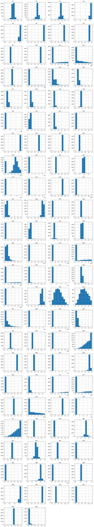

```python
# Histograms for each attribute
X_train_df.hist(layout=(dispRow,dispCol))
plt.show()
```

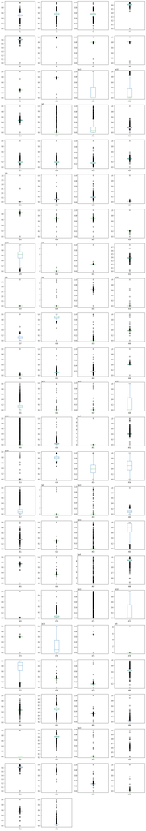

```python
# Box and Whisker plot for each attribute
X_train_df.plot(kind='box', subplots=True, layout=(dispRow,dispCol))
plt.show()
```

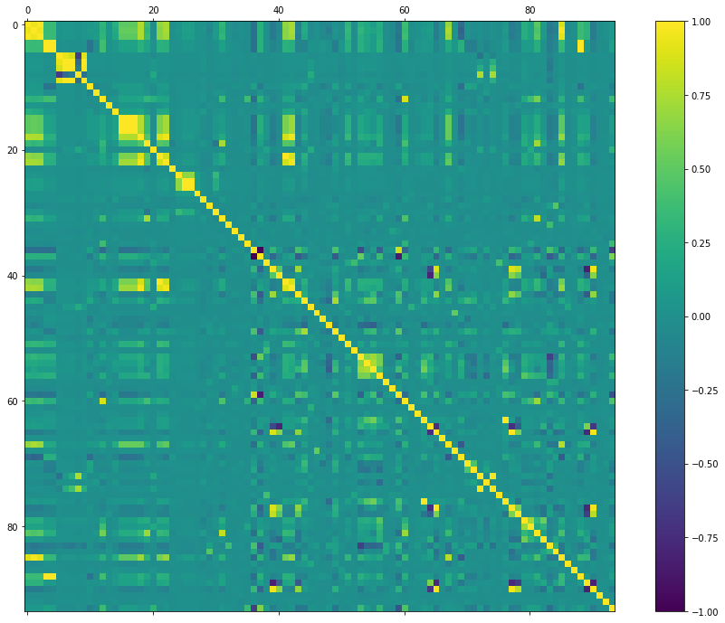

```python
# Correlation matrix
fig = plt.figure(figsize=(16,12))
ax = fig.add_subplot(111)
correlations = X_train_df.corr(method='pearson')
cax = ax.matshow(correlations, vmin=-1, vmax=1)
fig.colorbar(cax)
plt.show()
```

```python
if notifyStatus: status_notify("Task 2 - Summarize and Visualize Data completed! "+datetime.now().strftime('%a %B %d, %Y %I:%M:%S %p'))
```

## Task 3 - Pre-process Data

```python
if notifyStatus: status_notify("Task 3 - Pre-process Data has begun! "+datetime.now().strftime('%a %B %d, %Y %I:%M:%S %p'))
```

### 3.a) Training Data Balancing

```python
# Perform SMOTE transformation on the training data (Block #1 of 2)
X_train_imbal = X_train_df.values
y_train_imbal = y_train_df.values.ravel()
print("X_train_imbal.shape: {} y_train_imbal.shape: {}".format(X_train_imbal.shape, y_train_imbal.shape))
```

```
X_train_imbal.shape: (5455, 94) y_train_imbal.shape: (5455,)
```

```python
# Perform SMOTE transformation on the training data (Block #2 of 2)
print ('Original class distribution - 1: {} | 0: {}'.format((y_train_imbal==1).sum(), (y_train_imbal==0).sum()))
over_sample = SMOTE(sampling_strategy=0.6, random_state=seedNum)
under_sample = RandomUnderSampler(sampling_strategy=1.0, random_state=seedNum)
steps = [('o', over_sample), ('u', under_sample)]
sample_pipeline = Pipeline(steps=steps)
X_train, y_train = sample_pipeline.fit_resample(X_train_imbal, y_train_imbal)
print ('Resampled class distribution - 1: {} | 0: {}'.format((y_train==1).sum(), (y_train==0).sum()))
```

```
Original class distribution - 1: 176 | 0: 5279
Resampled class distribution - 1: 3167 | 0: 3167
```

### 3.b) Feature Scaling

```python
# Apply feature scaling and transformation
scaler = preprocessing.MinMaxScaler()
X_train = scaler.fit_transform(X_train)
print(X_train)
```

```
[[0.49553941 0.55162451 0.54146368 ... 0.02682768 0.18143344 0.03854421]
 [0.46682592 0.5412669  0.52138765 ... 0.02679116 0.18111642 0.04600523]
 [0.45273729 0.50528783 0.50329247 ... 0.02664756 0.17962425 0.01636886]
 ...
 [0.44202411 0.36184023 0.47949136 ... 0.02845019 0.18403902 0.01345246]
 [0.46321196 0.52611533 0.51642126 ... 0.0260456  0.157876   0.01993529]
 [0.45050241 0.50218869 0.49937291 ... 0.02628865 0.16797748 0.02319015]]
```

### 3.c) Feature Selection

```python
# Not applicable for this iteration of the project
```

### 3.d) Display the Final Datasets for Model-Building

```python
# Finalize the training dataset for the modeling activities
# class_encoder = preprocessing.LabelEncoder()
# y_train = class_encoder.fit_transform(y_train_df)
print("X_train.shape: {} y_train.shape: {}".format(X_train.shape, y_train.shape))
```

```
X_train.shape: (6334, 94) y_train.shape: (6334,)
```

```python
if notifyStatus: status_notify("Task 3 - Pre-process Data completed! "+datetime.now().strftime('%a %B %d, %Y %I:%M:%S %p'))
```

## Task 4 - Train and Evaluate Models

```python
if notifyStatus: status_notify("Task 4 - Train and Evaluate Models has begun! "+datetime.now().strftime('%a %B %d, %Y %I:%M:%S %p'))
```

### 4.a) Set test options and evaluation metric

```python
# Set up Algorithms Spot-Checking Array
startTimeModule = datetime.now()
# train_models = [('XGB', XGBClassifier(random_state=seedNum, n_jobs=n_jobs, objective='binary:logistic'))]
train_models = [('XGB', XGBClassifier(random_state=seedNum, n_jobs=n_jobs, objective='binary:logistic', tree_method='gpu_hist'))]
```

```python
# Generate model in turn
for name, model in train_models:
	if notifyStatus: status_notify("Algorithm "+name+" modeling has begun! "+datetime.now().strftime('%a %B %d, %Y %I:%M:%S %p'))
	startTimeModule = datetime.now()
	kfold = StratifiedKFold(n_splits=n_folds, shuffle=True, random_state=seedNum)
	cv_results = cross_val_score(model, X_train, y_train, cv=kfold, scoring=scoring, n_jobs=n_jobs, verbose=1)
	print("%s: %f (%f)" % (name, cv_results.mean(), cv_results.std()))
	print(model)
	print ('Model training time:', (datetime.now() - startTimeModule), '\n')
	if notifyStatus: status_notify("Algorithm "+name+" modeling completed! "+datetime.now().strftime('%a %B %d, %Y %I:%M:%S %p'))
```

```
[Parallel(n_jobs=1)]: Using backend SequentialBackend with 1 concurrent workers.
```

```
XGB: 0.964880 (0.001808)
XGBClassifier(base_score=0.5, booster='gbtree', colsample_bylevel=1,
              colsample_bynode=1, colsample_bytree=1, gamma=0,
              learning_rate=0.1, max_delta_step=0, max_depth=3,
              min_child_weight=1, missing=None, n_estimators=100, n_jobs=1,
              nthread=None, objective='binary:logistic', random_state=8,
              reg_alpha=0, reg_lambda=1, scale_pos_weight=1, seed=None,
              silent=None, subsample=1, tree_method='gpu_hist', verbosity=1)
Model training time: 0:00:01.432948
```

```
[Parallel(n_jobs=1)]: Done   5 out of   5 | elapsed:    1.4s finished
```

### 4.b) Algorithm Tuning

```python
# Set up the comparison array
tune_results = []
tune_model_names = []
```

```python
# Tuning XGBoost n_estimators, max_depth, and min_child_weight parameters
startTimeModule = datetime.now()
if notifyStatus: status_notify("Algorithm tuning iteration #1 has begun! "+datetime.now().strftime('%a %B %d, %Y %I:%M:%S %p'))

# tune_model1 = XGBClassifier(random_state=seedNum, n_jobs=n_jobs, objective='binary:logistic')
tune_model1 = XGBClassifier(random_state=seedNum, n_jobs=n_jobs, objective='binary:logistic', tree_method='gpu_hist')
tune_model_names.append('XGB_1')
paramGrid1 = dict(n_estimators=range(300,701,100), max_depth=np.array([3,6,9]), min_child_weight=np.array([1,2,3]))

kfold = StratifiedKFold(n_splits=n_folds, shuffle=True, random_state=seedNum)
grid1 = GridSearchCV(estimator=tune_model1, param_grid=paramGrid1, scoring=scoring, cv=kfold, n_jobs=n_jobs, verbose=1)
grid_result1 = grid1.fit(X_train, y_train)

print("Best: %f using %s" % (grid_result1.best_score_, grid_result1.best_params_))
tune_results.append(grid_result1.cv_results_['mean_test_score'])
means = grid_result1.cv_results_['mean_test_score']
stds = grid_result1.cv_results_['std_test_score']
params = grid_result1.cv_results_['params']
for mean, stdev, param in zip(means, stds, params):
    print("%f (%f) with: %r" % (mean, stdev, param))
print ('Model training time:',(datetime.now() - startTimeModule))
if notifyStatus: status_notify("Algorithm tuning iteration #1 completed! "+datetime.now().strftime('%a %B %d, %Y %I:%M:%S %p'))
```

```
[Parallel(n_jobs=1)]: Using backend SequentialBackend with 1 concurrent workers.
```

```
Fitting 5 folds for each of 45 candidates, totalling 225 fits
```

```
[Parallel(n_jobs=1)]: Done 225 out of 225 | elapsed:  3.5min finished
```

```
Best: 0.983801 using {'max_depth': 6, 'min_child_weight': 1, 'n_estimators': 500}
0.977925 (0.003904) with: {'max_depth': 3, 'min_child_weight': 1, 'n_estimators': 300}
0.980064 (0.003566) with: {'max_depth': 3, 'min_child_weight': 1, 'n_estimators': 400}
0.980835 (0.003595) with: {'max_depth': 3, 'min_child_weight': 1, 'n_estimators': 500}
0.982215 (0.003296) with: {'max_depth': 3, 'min_child_weight': 1, 'n_estimators': 600}
0.982366 (0.002967) with: {'max_depth': 3, 'min_child_weight': 1, 'n_estimators': 700}
0.978242 (0.004096) with: {'max_depth': 3, 'min_child_weight': 2, 'n_estimators': 300}
0.979775 (0.004292) with: {'max_depth': 3, 'min_child_weight': 2, 'n_estimators': 400}
0.981311 (0.003834) with: {'max_depth': 3, 'min_child_weight': 2, 'n_estimators': 500}
0.981144 (0.003535) with: {'max_depth': 3, 'min_child_weight': 2, 'n_estimators': 600}
0.981766 (0.003072) with: {'max_depth': 3, 'min_child_weight': 2, 'n_estimators': 700}
0.978068 (0.003340) with: {'max_depth': 3, 'min_child_weight': 3, 'n_estimators': 300}
0.980683 (0.002983) with: {'max_depth': 3, 'min_child_weight': 3, 'n_estimators': 400}
0.980987 (0.002658) with: {'max_depth': 3, 'min_child_weight': 3, 'n_estimators': 500}
0.981919 (0.002899) with: {'max_depth': 3, 'min_child_weight': 3, 'n_estimators': 600}
0.982063 (0.003413) with: {'max_depth': 3, 'min_child_weight': 3, 'n_estimators': 700}
0.982882 (0.001988) with: {'max_depth': 6, 'min_child_weight': 1, 'n_estimators': 300}
0.983036 (0.002068) with: {'max_depth': 6, 'min_child_weight': 1, 'n_estimators': 400}
0.983801 (0.001948) with: {'max_depth': 6, 'min_child_weight': 1, 'n_estimators': 500}
0.983649 (0.001981) with: {'max_depth': 6, 'min_child_weight': 1, 'n_estimators': 600}
0.983491 (0.002121) with: {'max_depth': 6, 'min_child_weight': 1, 'n_estimators': 700}
0.980869 (0.001592) with: {'max_depth': 6, 'min_child_weight': 2, 'n_estimators': 300}
0.981012 (0.002363) with: {'max_depth': 6, 'min_child_weight': 2, 'n_estimators': 400}
0.981469 (0.002099) with: {'max_depth': 6, 'min_child_weight': 2, 'n_estimators': 500}
0.982242 (0.002551) with: {'max_depth': 6, 'min_child_weight': 2, 'n_estimators': 600}
0.981785 (0.002896) with: {'max_depth': 6, 'min_child_weight': 2, 'n_estimators': 700}
0.980853 (0.000872) with: {'max_depth': 6, 'min_child_weight': 3, 'n_estimators': 300}
0.981464 (0.001715) with: {'max_depth': 6, 'min_child_weight': 3, 'n_estimators': 400}
0.981924 (0.001847) with: {'max_depth': 6, 'min_child_weight': 3, 'n_estimators': 500}
0.981924 (0.001847) with: {'max_depth': 6, 'min_child_weight': 3, 'n_estimators': 600}
0.981933 (0.002499) with: {'max_depth': 6, 'min_child_weight': 3, 'n_estimators': 700}
0.980554 (0.001987) with: {'max_depth': 9, 'min_child_weight': 1, 'n_estimators': 300}
0.981174 (0.002375) with: {'max_depth': 9, 'min_child_weight': 1, 'n_estimators': 400}
0.981150 (0.002805) with: {'max_depth': 9, 'min_child_weight': 1, 'n_estimators': 500}
0.980686 (0.003088) with: {'max_depth': 9, 'min_child_weight': 1, 'n_estimators': 600}
0.980840 (0.003243) with: {'max_depth': 9, 'min_child_weight': 1, 'n_estimators': 700}
0.980728 (0.003492) with: {'max_depth': 9, 'min_child_weight': 2, 'n_estimators': 300}
0.980875 (0.002809) with: {'max_depth': 9, 'min_child_weight': 2, 'n_estimators': 400}
0.981337 (0.003211) with: {'max_depth': 9, 'min_child_weight': 2, 'n_estimators': 500}
0.980877 (0.003042) with: {'max_depth': 9, 'min_child_weight': 2, 'n_estimators': 600}
0.981336 (0.003288) with: {'max_depth': 9, 'min_child_weight': 2, 'n_estimators': 700}
0.979921 (0.003390) with: {'max_depth': 9, 'min_child_weight': 3, 'n_estimators': 300}
0.980540 (0.003477) with: {'max_depth': 9, 'min_child_weight': 3, 'n_estimators': 400}
0.980696 (0.003963) with: {'max_depth': 9, 'min_child_weight': 3, 'n_estimators': 500}
0.981152 (0.003788) with: {'max_depth': 9, 'min_child_weight': 3, 'n_estimators': 600}
0.981002 (0.004002) with: {'max_depth': 9, 'min_child_weight': 3, 'n_estimators': 700}
Model training time: 0:03:31.070984
```

```python
# Tuning XGBoost subsample and colsample_bytree parameters
startTimeModule = datetime.now()
if notifyStatus: status_notify("Algorithm tuning iteration #2 has begun! "+datetime.now().strftime('%a %B %d, %Y %I:%M:%S %p'))

# tune_model2 = XGBClassifier(n_estimators=200, max_depth=6, min_child_weight=2, random_state=seedNum, n_jobs=n_jobs, objective='binary:logistic')
tune_model2 = XGBClassifier(n_estimators=500, max_depth=6, min_child_weight=1, random_state=seedNum, n_jobs=n_jobs, objective='binary:logistic', tree_method='gpu_hist')
tune_model_names.append('XGB_2')
paramGrid2 = dict(subsample=np.array([0.7,0.8,0.9,1.0]), colsample_bytree=np.array([0.7,0.8,0.9,1.0]))

kfold = StratifiedKFold(n_splits=n_folds, shuffle=True, random_state=seedNum)
grid2 = GridSearchCV(estimator=tune_model2, param_grid=paramGrid2, scoring=scoring, cv=kfold, n_jobs=n_jobs, verbose=1)
grid_result2 = grid2.fit(X_train, y_train)

print("Best: %f using %s" % (grid_result2.best_score_, grid_result2.best_params_))
tune_results.append(grid_result2.cv_results_['mean_test_score'])
means = grid_result2.cv_results_['mean_test_score']
stds = grid_result2.cv_results_['std_test_score']
params = grid_result2.cv_results_['params']
for mean, stdev, param in zip(means, stds, params):
    print("%f (%f) with: %r" % (mean, stdev, param))
print ('Model training time:',(datetime.now() - startTimeModule))
if notifyStatus: status_notify("Algorithm tuning iteration #2 completed! "+datetime.now().strftime('%a %B %d, %Y %I:%M:%S %p'))
```

```
Fitting 5 folds for each of 16 candidates, totalling 80 fits
```

```
[Parallel(n_jobs=1)]: Using backend SequentialBackend with 1 concurrent workers.
[Parallel(n_jobs=1)]: Done  80 out of  80 | elapsed:  1.4min finished
```

```
Best: 0.983801 using {'colsample_bytree': 1.0, 'subsample': 1.0}
0.982221 (0.001731) with: {'colsample_bytree': 0.7, 'subsample': 0.7}
0.982243 (0.001879) with: {'colsample_bytree': 0.7, 'subsample': 0.8}
0.981296 (0.001978) with: {'colsample_bytree': 0.7, 'subsample': 0.9}
0.982564 (0.002309) with: {'colsample_bytree': 0.7, 'subsample': 1.0}
0.982687 (0.002289) with: {'colsample_bytree': 0.8, 'subsample': 0.7}
0.983017 (0.002840) with: {'colsample_bytree': 0.8, 'subsample': 0.8}
0.982396 (0.003074) with: {'colsample_bytree': 0.8, 'subsample': 0.9}
0.983180 (0.001746) with: {'colsample_bytree': 0.8, 'subsample': 1.0}
0.982103 (0.003190) with: {'colsample_bytree': 0.9, 'subsample': 0.7}
0.982403 (0.002675) with: {'colsample_bytree': 0.9, 'subsample': 0.8}
0.982568 (0.002326) with: {'colsample_bytree': 0.9, 'subsample': 0.9}
0.982421 (0.003057) with: {'colsample_bytree': 0.9, 'subsample': 1.0}
0.982701 (0.001691) with: {'colsample_bytree': 1.0, 'subsample': 0.7}
0.982867 (0.002841) with: {'colsample_bytree': 1.0, 'subsample': 0.8}
0.982860 (0.002441) with: {'colsample_bytree': 1.0, 'subsample': 0.9}
0.983801 (0.001948) with: {'colsample_bytree': 1.0, 'subsample': 1.0}
Model training time: 0:01:24.431174
```

### 4.c) Compare Models After Tuning

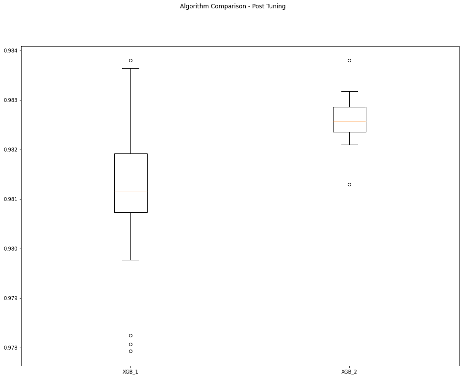

```python
fig = plt.figure(figsize=(16,12))
fig.suptitle('Algorithm Comparison - Post Tuning')
ax = fig.add_subplot(111)
plt.boxplot(tune_results)
ax.set_xticklabels(tune_model_names)
plt.show()
```

```python
if notifyStatus: status_notify("Task 4 - Train and Evaluate Models completed! "+datetime.now().strftime('%a %B %d, %Y %I:%M:%S %p'))
```

## Task 5 - Finalize Model and Present Analysis

```python
if notifyStatus: status_notify("Task 5 - Finalize Model and Present Analysis has begun! "+datetime.now().strftime('%a %B %d, %Y %I:%M:%S %p'))
```

```python
# test_model = XGBClassifier(n_estimators=500, max_depth=6, min_child_weight=1, colsample_bytree=1.0, subsample=1.0, random_state=seedNum, n_jobs=n_jobs, objective='binary:logistic')
test_model = XGBClassifier(n_estimators=500, max_depth=6, min_child_weight=1, colsample_bytree=1.0, subsample=1.0, random_state=seedNum, n_jobs=n_jobs, objective='binary:logistic', tree_method='gpu_hist')
test_model.fit(X_train, y_train)
print(test_model)
```

```
XGBClassifier(base_score=0.5, booster='gbtree', colsample_bylevel=1,
              colsample_bynode=1, colsample_bytree=1.0, gamma=0,
              learning_rate=0.1, max_delta_step=0, max_depth=6,
              min_child_weight=1, missing=None, n_estimators=500, n_jobs=1,
              nthread=None, objective='binary:logistic', random_state=8,
              reg_alpha=0, reg_lambda=1, scale_pos_weight=1, seed=None,
              silent=None, subsample=1.0, tree_method='gpu_hist', verbosity=1)
```

```python
# Apply feature scaling and transformation to the test dataset
X_test = scaler.transform(X_test_df)
print(X_test)
```

```
[[0.4803783  0.53418011 0.52909685 ... 0.02679126 0.18111736 0.13682596]
 [0.59103983 0.63939163 0.62010814 ... 0.02680203 0.18121303 0.05649015]
 [0.52985911 0.58722198 0.57481664 ... 0.02680978 0.18128072 0.03131672]
 ...
 [0.50684932 0.57168556 0.55763156 ... 0.02681569 0.18133176 0.07088829]
 [0.4680934  0.52523986 0.51924621 ... 0.02643608 0.17631452 0.06648556]
 [0.53531907 0.59757959 0.5870764  ... 0.02683167 0.18146678 0.04122032]]
```

```python
# Finalize the test dataset for the modeling testing
# X_test = X_test_df.to_numpy()
y_test = y_test_df.ravel()
print("X_test.shape: {} y_test.shape: {}".format(X_test.shape, y_test.shape))
```

```
X_test.shape: (1364, 94) y_test.shape: (1364,)
```

```python
test_predictions = test_model.predict(X_test)
print('F1 Score:', f1_score(y_test, test_predictions))
print('ROC/AUC Score:', roc_auc_score(y_test, test_predictions))
print(confusion_matrix(y_test, test_predictions))
print(classification_report(y_test, test_predictions))
```

```
F1 Score: 0.5818181818181818
ROC/AUC Score: 0.8507575757575758
[[1286   34]
 [  12   32]]
              precision    recall  f1-score   support

           0       0.99      0.97      0.98      1320
           1       0.48      0.73      0.58        44

    accuracy                           0.97      1364
   macro avg       0.74      0.85      0.78      1364
weighted avg       0.97      0.97      0.97      1364
```

```python
if notifyStatus: status_notify("Task 5 - Finalize Model and Present Analysis completed! "+datetime.now().strftime('%a %B %d, %Y %I:%M:%S %p'))
```

```python
print ('Total time for the script:',(datetime.now() - startTimeScript))
```

```
Total time for the script: 0:05:24.546576
```